# EDA Sterling E-Commerce

```python
#Importing all my necessary libraries for data analysis

import numpy as np #data analysis
import pandas as pd #data analysis

import matplotlib.pyplot as plt #data visualisation
%matplotlib inline
import seaborn as sns #data visualisation
import missingno as msno # Missing data-#data visualisation
from collections import Counter # Counting use capital C
```

```python
#load data set

df = pd.read_csv(r"C:\Users\22077\Downloads\Sterling_E_Commerce_Online_Sales_Data.csv")
df.head()
```

|  | Category | City | County | Cust Id | Customer Since | Date of Order | Full Name | Gender | Item Id | Order Id | Payment Method | Place Name | Ref Num | Region | State | User Name | Zip | Qty Ordered | Total |
| --- | --- | --- | --- | --- | --- | --- | --- | --- | --- | --- | --- | --- | --- | --- | --- | --- | --- | --- | --- |
| 0 | Health & Sports | Bode | Humboldt | 112285 | 2/11/2008 | 8/7/2022 0:00 | Renaud, Maudie | F | 880913 | 100547952.0 | Easypay_MA | Bode | 352808 | Midwest | IA | mcrenaud | 50519 | 3 | 32.0 |
| 1 | Men's Fashion | Belleville | St. Clair | 112386 | 6/23/2005 | 8/8/2022 0:00 | Shimp, Mariela | F | 881493 | 100548328.0 | Easypay_MA | Belleville | 310849 | Midwest | IL | mgshimp | 62223 | 2 | 74.8 |
| 2 | Men's Fashion | Belleville | St. Clair | 112386 | 6/23/2005 | 8/8/2022 0:00 | Shimp, Mariela | F | 881492 | 100548328.0 | Easypay_MA | Belleville | 310849 | Midwest | IL | mgshimp | 62223 | 2 | 74.9 |
| 3 | Computing | Young America | Carver | 112501 | 9/15/2013 | 8/18/2022 0:00 | Doiron, Latrina | F | 886067 | 100551079.0 | Payaxis | Young America | 578056 | Midwest | MN | lmdoiron | 55552 | 2 | 6822.9 |
| 4 | Entertainment | Young America | Carver | 112501 | 9/15/2013 | 8/20/2022 0:00 | Doiron, Latrina | F | 886878 | 100551618.0 | Payaxis | Young America | 578056 | Midwest | MN | lmdoiron | 55552 | 2 | 2849.9 |

```python
df.info()
```

```
<class 'pandas.core.frame.DataFrame'>
RangeIndex: 283083 entries, 0 to 283082
Data columns (total 19 columns):
 #   Column          Non-Null Count   Dtype
---  ------          --------------   -----
 0   Category        283083 non-null  object
 1   City            283083 non-null  object
 2   County          283083 non-null  object
 3   Cust Id         283083 non-null  int64
 4   Customer Since  283083 non-null  object
 5   Date of Order   283083 non-null  object
 6   Full Name       283083 non-null  object
 7   Gender          283083 non-null  object
 8   Item Id         283083 non-null  int64
 9   Order Id        283078 non-null  float64
 10  Payment Method  283083 non-null  object
 11  Place Name      283083 non-null  object
 12  Ref Num         283083 non-null  int64
 13  Region          283083 non-null  object
 14  State           283083 non-null  object
 15  User Name       283083 non-null  object
 16  Zip             283083 non-null  int64
 17  Qty Ordered     283083 non-null  int64
 18  Total           283083 non-null  float64
dtypes: float64(2), int64(5), object(12)
memory usage: 41.0+ MB
```

```python
#Checking any null values

df.isnull()
```

|  | Category | City | County | Cust Id | Customer Since | Date of Order | Full Name | Gender | Item Id | Order Id | Payment Method | Place Name | Ref Num | Region | State | User Name | Zip | Qty Ordered | Total |
| --- | --- | --- | --- | --- | --- | --- | --- | --- | --- | --- | --- | --- | --- | --- | --- | --- | --- | --- | --- |
| 0 | False | False | False | False | False | False | False | False | False | False | False | False | False | False | False | False | False | False | False |
| 1 | False | False | False | False | False | False | False | False | False | False | False | False | False | False | False | False | False | False | False |
| 2 | False | False | False | False | False | False | False | False | False | False | False | False | False | False | False | False | False | False | False |
| 3 | False | False | False | False | False | False | False | False | False | False | False | False | False | False | False | False | False | False | False |
| 4 | False | False | False | False | False | False | False | False | False | False | False | False | False | False | False | False | False | False | False |
| ... | ... | ... | ... | ... | ... | ... | ... | ... | ... | ... | ... | ... | ... | ... | ... | ... | ... | ... | ... |
| 283078 | False | False | False | False | False | False | False | False | False | False | False | False | False | False | False | False | False | False | False |
| 283079 | False | False | False | False | False | False | False | False | False | False | False | False | False | False | False | False | False | False | False |
| 283080 | False | False | False | False | False | False | False | False | False | False | False | False | False | False | False | False | False | False | False |
| 283081 | False | False | False | False | False | False | False | False | False | False | False | False | False | False | False | False | False | False | False |
| 283082 | False | False | False | False | False | False | False | False | False | False | False | False | False | False | False | False | False | False | False |

283083 rows × 19 columns

```python
df.isnull().sum()

#checking all null values in each feature
```

```
Category          0
City              0
County            0
Cust Id           0
Customer Since    0
Date of Order     0
Full Name         0
Gender            0
Item Id           0
Order Id          5
Payment Method    0
Place Name        0
Ref Num           0
Region            0
State             0
User Name         0
Zip               0
Qty Ordered       0
Total             0
dtype: int64
```

```python
df['Order Id'].isnull().sum()
```

```
5
```

```python
# Filtering to know where the null values are in the column 'Order Id'


df[df['Order Id'].isnull()]g
```

|  | Category | City | County | Cust Id | Customer Since | Date of Order | Full Name | Gender | Item Id | Order Id | Payment Method | Place Name | Ref Num | Region | State | User Name | Zip | Qty Ordered | Total |
| --- | --- | --- | --- | --- | --- | --- | --- | --- | --- | --- | --- | --- | --- | --- | --- | --- | --- | --- | --- |
| 38758 | Soghaat | Leiters Ford | Fulton | 111867 | 11/4/2010 | 8/4/2022 0:00 | Wright, Man | M | 879766 | NaN | cod | Leiters Ford | 939999 | Midwest | IN | mewright | 46945 | 2 | 36.0 |
| 38759 | Soghaat | Leiters Ford | Fulton | 111867 | 11/4/2010 | 8/4/2022 0:00 | Wright, Man | M | 879765 | NaN | cod | Leiters Ford | 939999 | Midwest | IN | mewright | 46945 | 3 | 45.0 |
| 133217 | Mobiles & Tablets | Rock Point | Charles | 92075 | 4/8/2014 | 4/1/2022 0:00 | Torkelson, Berneice | F | 767619 | NaN | cod | Rock Point | 715389 | South | MD | bttorkelson | 20682 | 2 | 2919.9 |
| 145889 | Mobiles & Tablets | Uniopolis | Auglaize | 111166 | 2/23/2017 | 7/21/2022 0:00 | Cannon, Shamika | F | 872703 | NaN | cod | Uniopolis | 406105 | Midwest | OH | svcannon | 45888 | 2 | 578.9 |
| 224999 | Computing | Barrington | Camden | 40853 | 8/24/2009 | 8/12/2022 0:00 | Robichaux, Marion | M | 883358 | NaN | cod | Barrington | 986961 | Northeast | NJ | mjrobichaux | 8007 | 2 | 39.9 |

The Numbers of the rows with null values in the 'Order Id' column is relatively small. I will be droping those rows

```
Category          0
City              0
County            0
Cust Id           0
Customer Since    0
Date of Order     0
Full Name         0
Gender            0
Item Id           0
Order Id          5
Payment Method    0
Place Name        0
Ref Num           0
Region            0
State             0
User Name         0
Zip               0
Qty Ordered       0
Total             0
dtype: int64
```

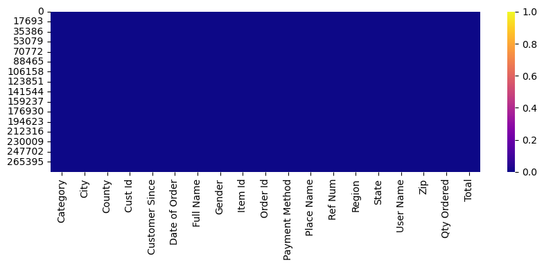

```python
df.isnull().sum() # you can also use df.isna().sum()
print (df.isnull().sum())

#visuliasing the missing data

plt.figure(figsize = (10,3))

sns.heatmap(df.isnull(), cbar = True, cmap = 'plasma')
```

```python
corr_matrix = df.corr()
```

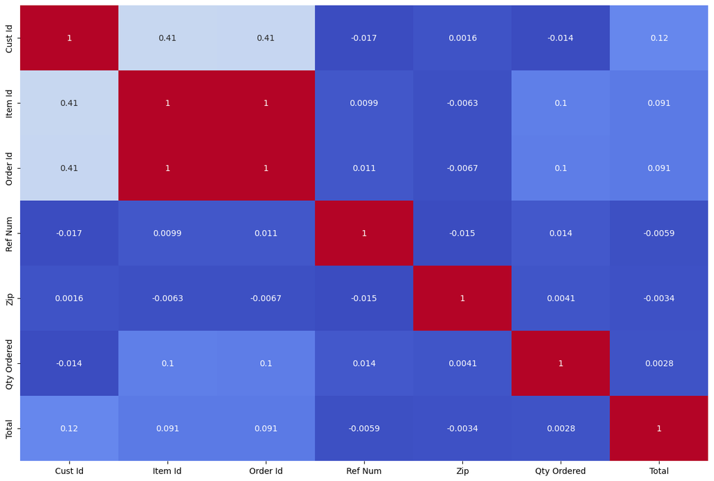

```python
## plotting the correlation or relationship between each parameter of the character or column

plt.figure(figsize = (15,10))


sns.heatmap(corr_matrix, cmap='coolwarm', annot=True, cbar=False)
```

```python
df.dropna(subset=['Order Id'], inplace=True)
```

```python
df['Category'].unique()
```

```
array(['Health & Sports', "Men's Fashion", 'Computing', 'Entertainment',
       'Mobiles & Tablets', 'Superstore', 'Appliances',
       'Beauty & Grooming', 'Home & Living', 'Soghaat', "Women's Fashion",
       'School & Education', 'Books', 'Kids & Baby', 'Others'],
      dtype=object)
```

```python
df['Payment Method'].unique()
```

```
array(['Easypay_MA', 'Payaxis', 'apg', 'bankalfalah', 'cod',
       'customercredit', 'easypay_voucher', 'Easypay', 'jazzvoucher',
       'jazzwallet', 'mcblite', 'cashatdoorstep', 'financesettlement'],
      dtype=object)
```

```python
df['Region'].unique()
```

```
array(['Midwest', 'West', 'South', 'Northeast'], dtype=object)
```

```python
# I am changing my date format from object to int and break it down to year, months, and weeks

df['Date of Order'] = pd.to_datetime(df['Date of Order'])
df['Date of Order']
```

```
0        2022-08-07
1        2022-08-08
2        2022-08-08
3        2022-08-18
4        2022-08-20
            ...
283078   2021-12-30
283079   2021-12-30
283080   2021-12-30
283081   2021-12-30
283082   2021-12-30
Name: Date of Order, Length: 283078, dtype: datetime64[ns]
```

```python
# Year

df['Date of Order'].dt.year
```

```
0         2022
1         2022
2         2022
3         2022
4         2022
          ...
283078    2021
283079    2021
283080    2021
283081    2021
283082    2021
Name: Date of Order, Length: 283078, dtype: int64
```

```python
# Month

df['Date of Order'].dt.month
```

```
0          8
1          8
2          8
3          8
4          8
          ..
283078    12
283079    12
283080    12
283081    12
283082    12
Name: Date of Order, Length: 283078, dtype: int64
```

```python
# Now i am adding the column to the table

df['year'] = df['Date of Order'].dt.year

df['month'] = df['Date of Order'].dt.month

df.head(1)
```

|  | Category | City | County | Cust Id | Customer Since | Date of Order | Full Name | Gender | Item Id | Order Id | ... | Place Name | Ref Num | Region | State | User Name | Zip | Qty Ordered | Total | year | month |
| --- | --- | --- | --- | --- | --- | --- | --- | --- | --- | --- | --- | --- | --- | --- | --- | --- | --- | --- | --- | --- | --- |
| 0 | Health & Sports | Bode | Humboldt | 112285 | 2/11/2008 | 2022-08-07 | Renaud, Maudie | F | 880913 | 100547952.0 | ... | Bode | 352808 | Midwest | IA | mcrenaud | 50519 | 3 | 32.0 | 2022 | 8 |

1 rows × 21 columns

```python
# Now i am calculating my total sales by multiplying Qty ordered with Total
# Create a new column 'Revenue' by multiplying 'Qty' with 'Total'


df['Revenue'] = df['Qty Ordered'] * df['Total']

# Display the DataFrame with the new 'Revenue' column
```

```python
df.head(1)
```

|  | Category | City | County | Cust Id | Customer Since | Date of Order | Full Name | Gender | Item Id | Order Id | ... | Ref Num | Region | State | User Name | Zip | Qty Ordered | Total | year | month | Revenue |
| --- | --- | --- | --- | --- | --- | --- | --- | --- | --- | --- | --- | --- | --- | --- | --- | --- | --- | --- | --- | --- | --- |
| 0 | Health & Sports | Bode | Humboldt | 112285 | 2/11/2008 | 2022-08-07 | Renaud, Maudie | F | 880913 | 100547952.0 | ... | 352808 | Midwest | IA | mcrenaud | 50519 | 3 | 32.0 | 2022 | 8 | 96.0 |

1 rows × 22 columns

# Now I have my data set for exploratory analysis

### Univariate analysis

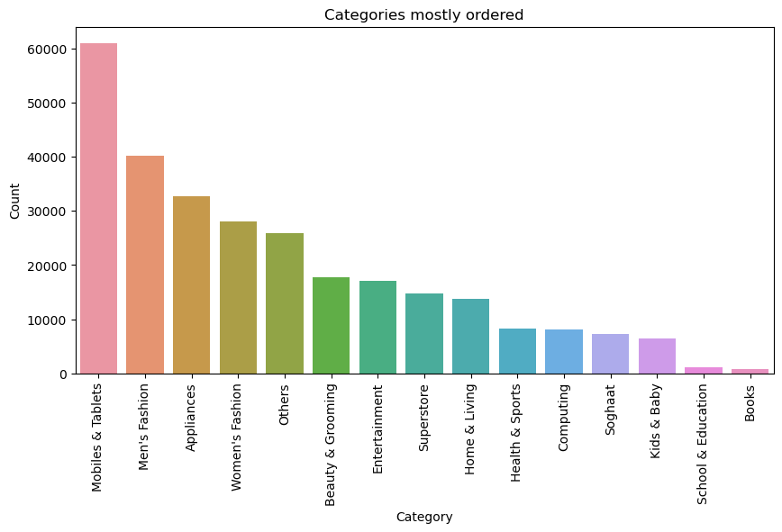

```python
# I want to see the category that is mostly ordered

plt.figure(figsize = (10,5))

category_counts = df['Category'].value_counts()
category_order = category_counts.index

sns.countplot(x='Category', data=df, order = category_order)
plt.xlabel("Category")
plt.ylabel('Count')
plt.title('Categories mostly ordered')
plt.xticks(rotation=90)
plt.show();
```

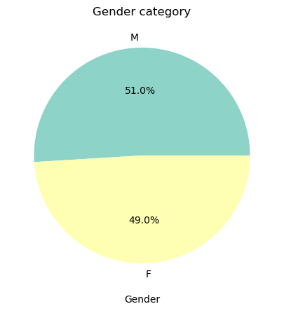

```python
# i am using a pie chart for the gender

plt.figure(figsize=(8, 5))

# Calculate the count of each gender category
gender_counts = df['Gender'].value_counts()

# Create the pie chart with percentages
plt.pie(gender_counts, labels=gender_counts.index, autopct='%1.1f%%', colors=sns.color_palette('Set3'))
plt.xlabel("Gender")
plt.title('Gender category')

plt.show()
```

Male gender are slightly above the female gender

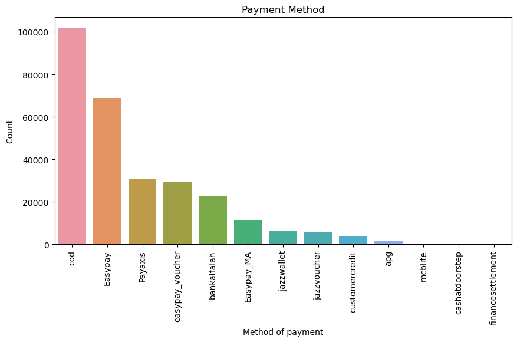

```python
# Visualising the data based on the payment method

plt.figure(figsize=(10, 5))

# Calculate the count of each payment method and sort in descending order
payment_counts = df['Payment Method'].value_counts()
payment_order = payment_counts.index

sns.countplot(x='Payment Method', data=df, order=payment_order)
plt.xlabel("Method of payment")
plt.ylabel('Count')
plt.title('Payment Method')
plt.xticks(rotation=90)
plt.show()
```

The largest payment method is cod, easy pay, payaxis, and easy pay voucher. the leasts are apg, mcbite, cash at door step and finanace settlement

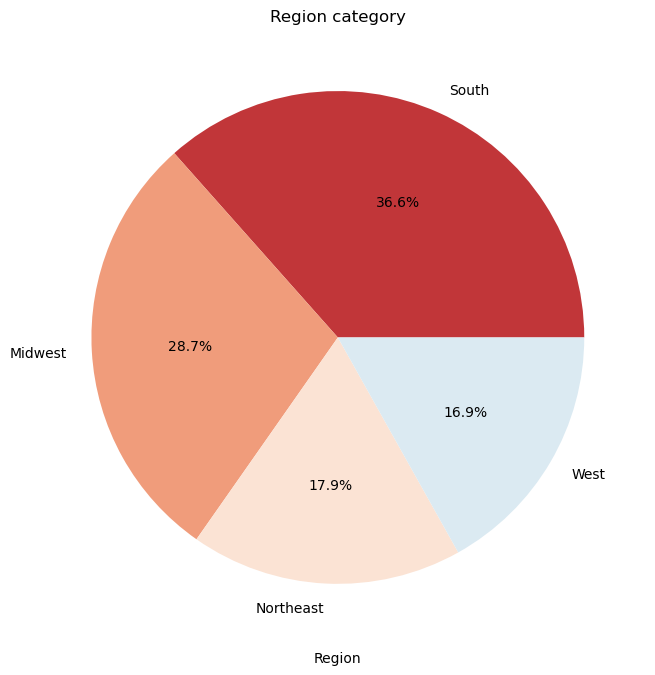

```python
# The highest region visualisation

plt.figure(figsize=(15, 8))

# Calculate the count of each region category
region_counts = df['Region'].value_counts()

# Create the pie chart with percentages
plt.pie(region_counts, labels=region_counts.index, autopct='%1.1f%%', colors=sns.color_palette('RdBu'))
plt.xlabel("Region")
plt.title('Region category')

plt.show()
```

The souht and the Midwest region are the largest category here while the west is the least

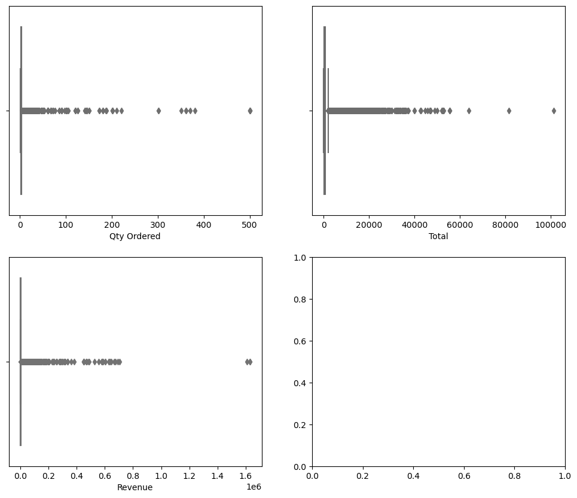

```python
#

# I am checking on the qty ordered, Totals, and Revenue for outliers

# Create a figure and axis objects for subplots
fig, axes = plt.subplots(nrows=2, ncols=2, figsize=(12, 10))

# Box plot for 'Quantity' with a specific color
sns.boxplot(x=df['Qty Ordered'], ax=axes[0, 0], color='skyblue')
axes[0, 0].set_xlabel('Qty Ordered')

# Box plot for 'Total' with a different color
sns.boxplot(x=df['Total'], ax=axes[0, 1], color='salmon')
axes[0, 1].set_xlabel('Total')

# Box plot for 'Revenue' with another color
sns.boxplot(x=df['Revenue'], ax=axes[1, 0], color='lightgreen')
axes[1, 0].set_xlabel('Revenue')

# Box plot for 'max_hr' with a different color
```

No significant insight here

### Bivariate Analysis

```
Mobiles & Tablets     60952
Men's Fashion         40183
Appliances            32693
Women's Fashion       28003
Others                25913
Beauty & Grooming     17723
Entertainment         17120
Superstore            14815
Home & Living         13815
Health & Sports        8347
Computing              8024
Soghaat                7187
Kids & Baby            6421
School & Education     1078
Books                   804
Name: Category, dtype: int64
```

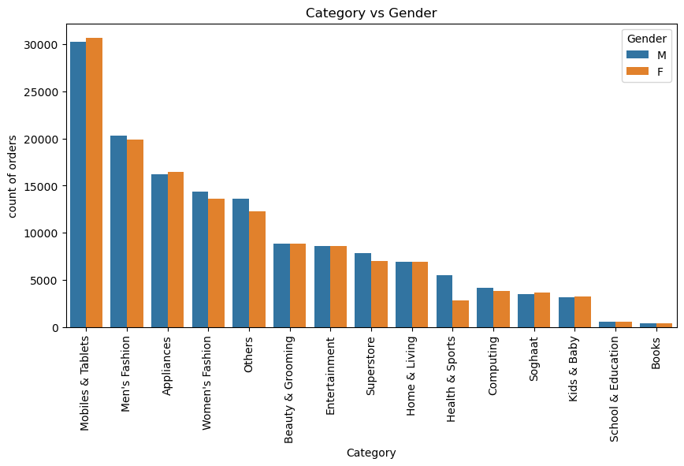

```python
# categorical variable of gender vs category


print (df['Category'].value_counts())

category_counts = df['Category'].value_counts()
category_order = category_counts.index

plt.figure(figsize = (10,5))

sns.countplot(x='Category', data=df, hue='Gender', order = category_order)
plt.xlabel("Category")
plt.ylabel('count of orders')
plt.title('Category vs Gender')
plt.xticks(rotation=90)
plt.show();
```

The Female gender tends to buy slightly higher in mobiles and appliances. The male gender slight purches more in men and women's fashion, 'others category' and fitness and sports

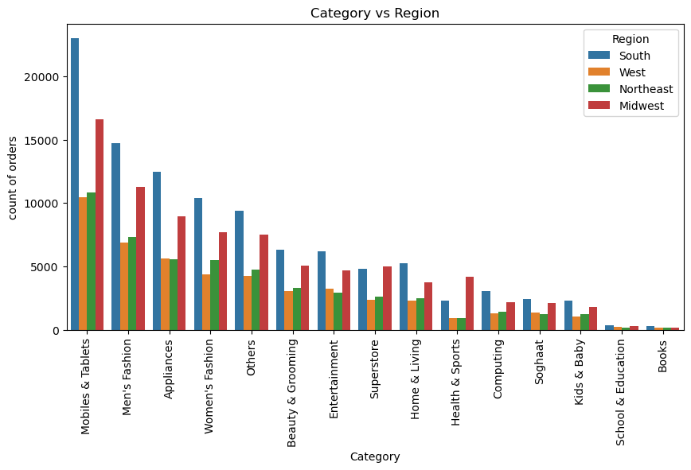

```python
# print (df['Category'].value_counts())

category_counts = df['Category'].value_counts()
category_order = category_counts.index

plt.figure(figsize = (10,5))

sns.countplot(x='Category', data=df, hue='Region', order = category_order)
plt.xlabel("Category")
plt.ylabel('count of orders')
plt.title('Category vs Region')
plt.xticks(rotation=90)
plt.show();
```

The South and the Midwest are the largest region purchasing more from the company.

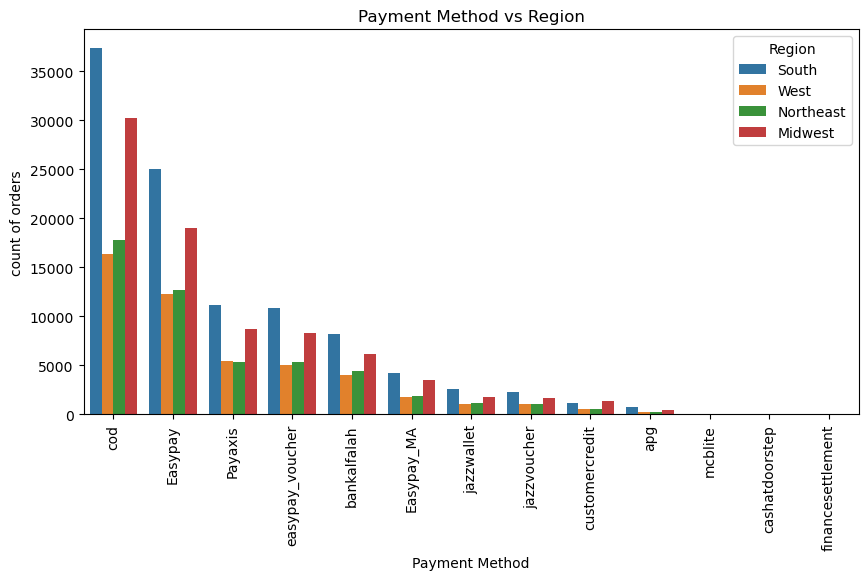

```python
# print (df['Category'].value_counts())

category_counts = df['Payment Method'].value_counts()
category_order = category_counts.index

plt.figure(figsize = (10,5))

sns.countplot(x='Payment Method', data=df, hue='Region', order = category_order)
plt.xlabel("Payment Method")
plt.ylabel('count of orders')
plt.title('Payment Method vs Region')
plt.xticks(rotation=90)
plt.show();
```

[figure not shown]

```python
# visualise the category and revenue generated

# print (df['Category'].value_counts())

category_counts = df['Category'].value_counts()
category_order = category_counts.index

plt.figure(figsize=(10, 5))

# Create the bar chart using sns.barplot()
#bar_plot = sns.barplot(x='Category', y='Revenue', data=df, order=category_order)
#plt.xlabel("Category")
#plt.ylabel('Revenue')
#plt.title('Category vs Revenue')

# Draw a line graph using plt.plot()
category_counts = df['Category'].value_counts()
category_order = category_counts.index

plt.figure(figsize=(10, 5))


# Add labels to each bar in the bar chart
#for index, value in enumerate(df.groupby('Category')['Revenue'].sum()):
    #bar_plot.text(index, value, str(value), ha='center', va='bottom', fontsize=10)

plt.legend(line_plot, ['Total Revenue'], loc='upper right')
plt.show()
```

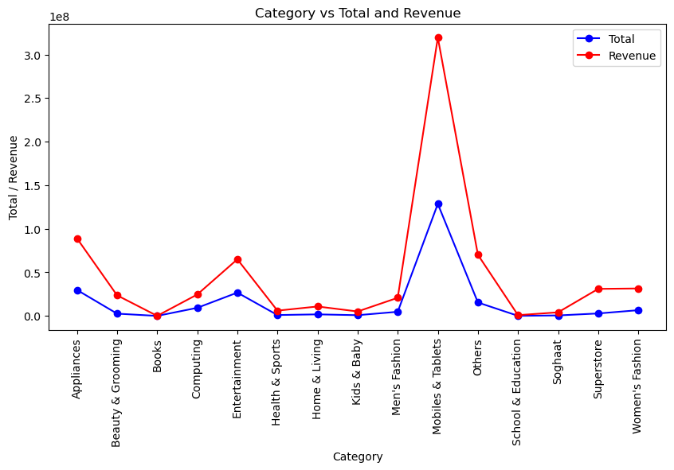

```python
# Visualise the quantity ordered vs revenue for each category

category_counts = df['Category'].value_counts()
category_order = category_counts.index

plt.figure(figsize=(10, 5))

# Line graph for 'Qty Ordered'
plt.plot(df.groupby('Category')['Total'].sum(), color='blue', marker='o', label='Total')

# Line graph for 'Revenue'
plt.plot(df.groupby('Category')['Revenue'].sum(), color='red', marker='o', label='Revenue')

# Set x-axis and y-axis labels
plt.xlabel("Category")
plt.ylabel('Total / Revenue')
plt.title('Category vs Total and Revenue')
plt.xticks(rotation=90)

# Display the legend
plt.legend(loc='upper right')

plt.show()
```